# Working with categorical predictors

Matthew Rudd

3/3/2022

The primary message in the first example is:

> *Categorical data is not quantitative!*

# Logistic regression: violet data

Load the violet data and compute the bud formation rates for each plot:

```r
library(tidyverse)
violets <- read_csv("violets.csv")
violets <- violets %>%
  mutate(Bud = as.numeric( `Bud counts` > 0 ))

(violet_plots <- violets %>%
  group_by(Plot) %>%
  summarize( N = n(),
             Rate = mean(Bud)) )
```

```
## # A tibble: 10 × 3
##     Plot     N  Rate
##    <dbl> <int> <dbl>
##  1     1    32 0.25
##  2     2    32 0.5
##  3     3    32 0.438
##  4     4    32 0.438
##  5     5    32 0.469
##  6     6    32 0.5
##  7     7    32 0.469
##  8     8    32 0.5
##  9     9    32 0.469
## 10    10    32 0.469
```

The different plots are numbered 1 through 10; by default, R therefore considers `Plot` to be a numeric variable, which we can confirm by checking its type:

```r
class(violets$Plot)
```

```
## [1] "numeric"
```

What could go wrong?

## Useless model when `Plot` is numeric

If we fit a logistic model now, using `Plot` as a *quantitative* variable, the results are terrible:

```r
violet.fit <- glm( Bud ~ Plot, data=violets, family="binomial")
summary( violet.fit )
```

```
##
## Call:
## glm(formula = Bud ~ Plot, family = "binomial", data = violets)
##
## Deviance Residuals:
##     Min       1Q   Median       3Q      Max
## -1.1945  -1.1041  -0.9957   1.2526   1.3707
##
## Coefficients:
##             Estimate Std. Error z value Pr(>|z|)
## (Intercept) -0.49752    0.24545  -2.027   0.0427 *
## Plot         0.05376    0.03933   1.367   0.1717
## ---
## Signif. codes:  0 '***' 0.001 '**' 0.01 '*' 0.05 '.' 0.1 ' ' 1
##
## (Dispersion parameter for binomial family taken to be 1)
##
##     Null deviance: 440.41  on 319  degrees of freedom
## Residual deviance: 438.53  on 318  degrees of freedom
## AIC: 442.53
##
## Number of Fisher Scoring iterations: 4
```

```r
violet_plots <- violet_plots %>%
  mutate( Fit = predict( violet.fit,
                         newdata = data.frame(Plot = 1:10),
                         type = "response"))

violet_plots
```

```
## # A tibble: 10 × 4
##     Plot     N  Rate   Fit
##    <dbl> <int> <dbl> <dbl>
##  1     1    32 0.25  0.391
##  2     2    32 0.5   0.404
##  3     3    32 0.438 0.417
##  4     4    32 0.438 0.430
##  5     5    32 0.469 0.443
##  6     6    32 0.5   0.456
##  7     7    32 0.469 0.470
##  8     8    32 0.5   0.483
##  9     9    32 0.469 0.497
## 10    10    32 0.469 0.510
```

The fitted values, which should correspond to the probabilities of bud formation in each plot, are not good estimates of the empirical rates.

## Reasonable model when `Plot` is categorical

Once we recognize that `Plot` is categorical and convert it into a factor, the resulting logistic model works well:

```r
violets$Plot <- as.factor( violets$Plot )
violet.fit <- glm( Bud ~ Plot, data=violets, family="binomial")
summary( violet.fit )
```

```
##
## Call:
## glm(formula = Bud ~ Plot, family = "binomial", data = violets)
##
## Deviance Residuals:
##     Min       1Q   Median       3Q      Max
## -1.1774  -1.1247  -0.7585   1.2310   1.6651
##
## Coefficients:
##             Estimate Std. Error z value Pr(>|z|)
## (Intercept)  -1.0986     0.4082  -2.691  0.00712 **
## Plot2         1.0986     0.5401   2.034  0.04193 *
## Plot3         0.8473     0.5419   1.564  0.11792
## Plot4         0.8473     0.5419   1.564  0.11792
## Plot5         0.9734     0.5405   1.801  0.07171 .
## Plot6         1.0986     0.5401   2.034  0.04193 *
## Plot7         0.9734     0.5405   1.801  0.07171 .
## Plot8         1.0986     0.5401   2.034  0.04193 *
## Plot9         0.9734     0.5405   1.801  0.07171 .
## Plot10        0.9734     0.5405   1.801  0.07171 .
## ---
## Signif. codes:  0 '***' 0.001 '**' 0.01 '*' 0.05 '.' 0.1 ' ' 1
##
## (Dispersion parameter for binomial family taken to be 1)
##
##     Null deviance: 440.41  on 319  degrees of freedom
## Residual deviance: 433.74  on 310  degrees of freedom
## AIC: 453.74
##
## Number of Fisher Scoring iterations: 4
```

```r
violet_plots <- violet_plots %>%
  mutate( Fit = predict( violet.fit,
                         newdata = data.frame(Plot = levels(violets$Plot)),
                         type = "response"))

violet_plots
```

```
## # A tibble: 10 × 4
##     Plot     N  Rate   Fit
##    <dbl> <int> <dbl> <dbl>
##  1     1    32 0.25  0.250
##  2     2    32 0.5   0.500
##  3     3    32 0.438 0.437
##  4     4    32 0.438 0.437
##  5     5    32 0.469 0.469
##  6     6    32 0.5   0.500
##  7     7    32 0.469 0.469
##  8     8    32 0.5   0.500
##  9     9    32 0.469 0.469
## 10    10    32 0.469 0.469
```

This is what happens when working with one categorical predictor:

> *the model predictions are the group averages.*

In this case, the average for a group (a plot) is the empirical probability of bud formation, i.e., the percentage of days on which new buds were observed in a given plot.

# Linear regression: infant mortality rates by continent

## Visualize the data and examine the summary stats

```r
imr <- read_csv("imr2011.csv")
```

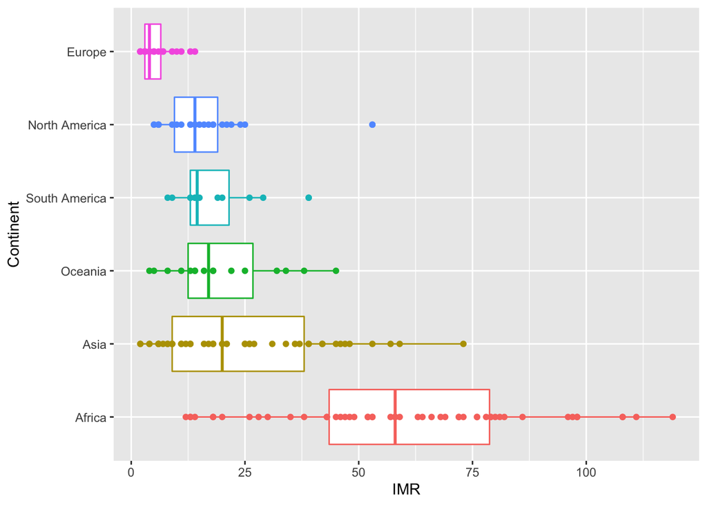

```r
imr$Continent <- as.factor(imr$Continent)
imr <- imr %>%
  mutate( Continent = fct_reorder(Continent, -IMR))

ggplot( imr, aes( x=IMR, y=Continent, color=Continent)) +
  geom_boxplot() +
  geom_point() +
  theme( legend.position = "none")
```

```r
imr_means <- imr %>%
  group_by(Continent) %>%
  summarize( Mean = mean(IMR))

imr_means %>%
  arrange(Mean)
```

```
## # A tibble: 6 × 2
##   Continent      Mean
##   <fct>         <dbl>
## 1 Europe         4.98
## 2 North America 15.7
## 3 South America 18.2
## 4 Oceania       19.8
## 5 Asia          24.1
## 6 Africa        60.1
```

### Linear regression model

```r
imr.fit <- lm( IMR ~ Continent, data = imr )
summary(imr.fit)
```

```
##
## Call:
## lm(formula = IMR ~ Continent, data = imr)
##
## Residuals:
##     Min      1Q  Median      3Q     Max
## -48.056  -8.459  -1.977   7.322  58.944
##
## Coefficients:
##                        Estimate Std. Error t value Pr(>|t|)
## (Intercept)              60.056      2.439  24.623  < 2e-16 ***
## ContinentAsia           -35.949      3.575 -10.055  < 2e-16 ***
## ContinentOceania        -40.243      5.102  -7.888 2.39e-13 ***
## ContinentSouth America  -41.806      5.720  -7.309 7.38e-12 ***
## ContinentNorth America  -44.360      4.463  -9.940  < 2e-16 ***
## ContinentEurope         -55.079      3.663 -15.036  < 2e-16 ***
## ---
## Signif. codes:  0 '***' 0.001 '**' 0.01 '*' 0.05 '.' 0.1 ' ' 1
##
## Residual standard error: 17.92 on 189 degrees of freedom
## Multiple R-squared:  0.5824, Adjusted R-squared:  0.5714
## F-statistic: 52.73 on 5 and 189 DF,  p-value: < 2.2e-16
```

```r
imr_means <- imr_means %>%
  mutate( Fit = predict( imr.fit,
                         newdata = data.frame(Continent = levels(imr$Continent))))
imr_means %>% arrange(Mean)
```

```
## # A tibble: 6 × 3
##   Continent      Mean   Fit
##   <fct>         <dbl> <dbl>
## 1 Europe         4.98  4.98
## 2 North America 15.7  15.7
## 3 South America 18.2  18.3
## 4 Oceania       19.8  19.8
## 5 Asia          24.1  24.1
## 6 Africa        60.1  60.1
```

# Linear regression with 2 predictors

```r
heights <- read_csv("all_heights.csv")
```

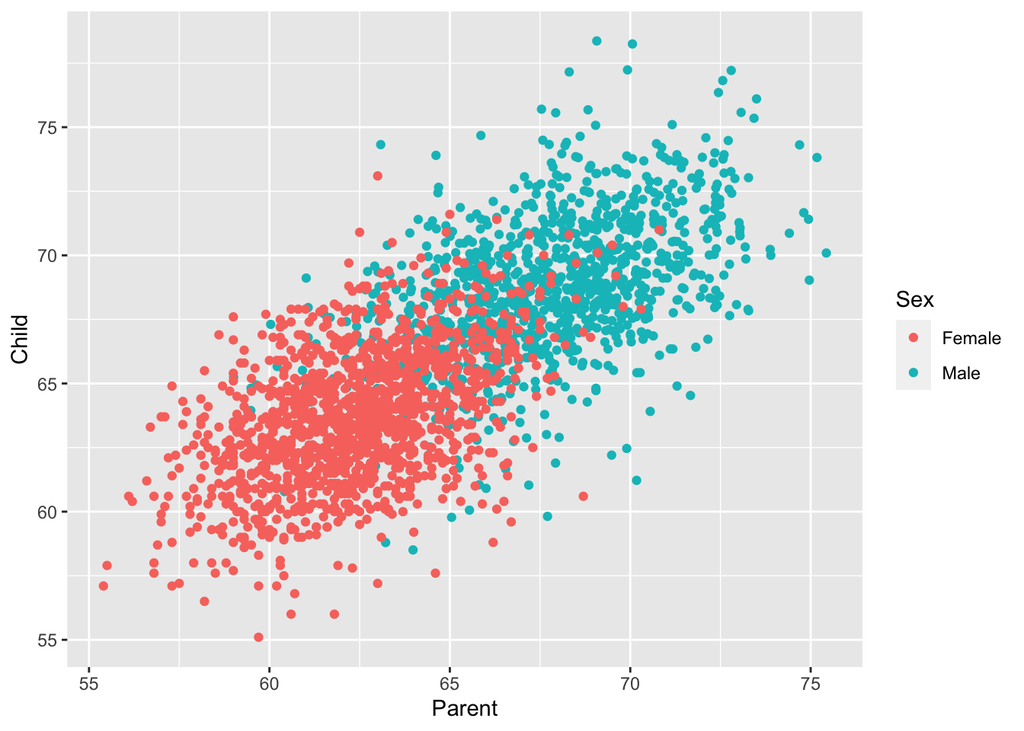

```r
ggplot( heights, aes(x=Parent, y=Child, color=Sex)) +
  geom_point()
```

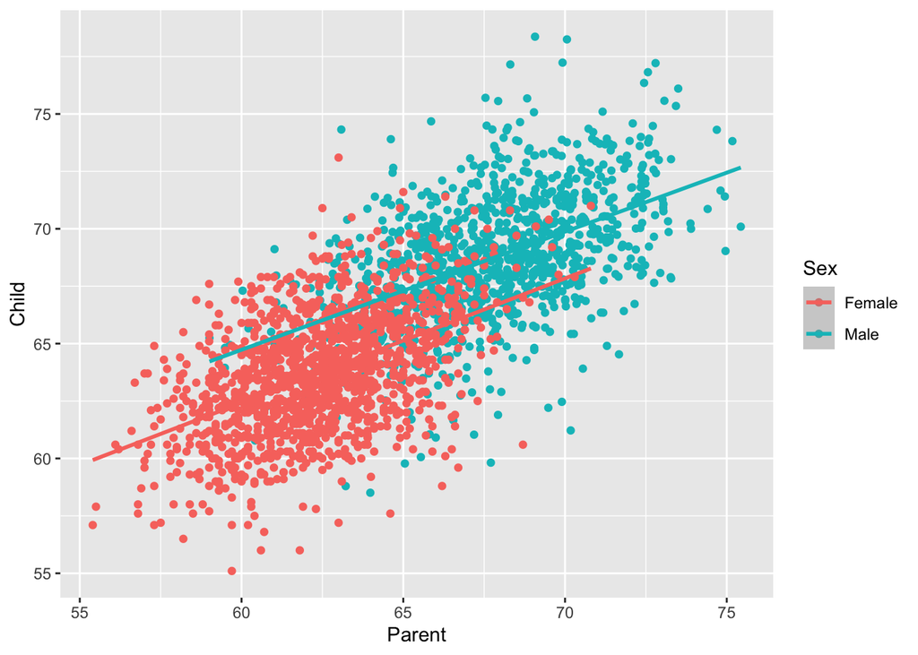

```r
ggplot( heights, aes(x=Parent, y=Child, color=Sex)) +
  geom_point() +
  geom_smooth( method="lm", level=0)
```

```r
# no interaction
heights.fit <- lm( Child ~ Parent + Sex, data=heights)
summary(heights.fit)
```

```
##
## Call:
## lm(formula = Child ~ Parent + Sex, data = heights)
##
## Residuals:
##     Min      1Q  Median      3Q     Max
## -8.8774 -1.5309  0.0065  1.5360  9.0603
##
## Coefficients:
##             Estimate Std. Error t value Pr(>|t|)
## (Intercept) 30.80806    1.16792   26.38   <2e-16 ***
## Parent       0.52749    0.01867   28.25   <2e-16 ***
## SexMale      2.17199    0.13651   15.91   <2e-16 ***
## ---
## Signif. codes:  0 '***' 0.001 '**' 0.01 '*' 0.05 '.' 0.1 ' ' 1
##
## Residual standard error: 2.342 on 2450 degrees of freedom
## Multiple R-squared:  0.5867, Adjusted R-squared:  0.5864
## F-statistic:  1739 on 2 and 2450 DF,  p-value: < 2.2e-16
```

```r
#with interaction
heights.fit <- lm( Child ~ Parent*Sex, data=heights)
summary(heights.fit)
```

```
##
## Call:
## lm(formula = Child ~ Parent * Sex, data = heights)
##
## Residuals:
##     Min      1Q  Median      3Q     Max
## -8.8772 -1.5267  0.0153  1.5358  9.0525
##
## Coefficients:
##                Estimate Std. Error t value Pr(>|t|)
## (Intercept)    29.91744    1.67711  17.839   <2e-16 ***
## Parent          0.54175    0.02683  20.188   <2e-16 ***
## SexMale         3.96917    2.43236   1.632    0.103
## Parent:SexMale -0.02765    0.03737  -0.740    0.459
## ---
## Signif. codes:  0 '***' 0.001 '**' 0.01 '*' 0.05 '.' 0.1 ' ' 1
##
## Residual standard error: 2.343 on 2449 degrees of freedom
## Multiple R-squared:  0.5868, Adjusted R-squared:  0.5863
## F-statistic:  1159 on 3 and 2449 DF,  p-value: < 2.2e-16
```